# A3: Incarceration

Eun Be Cha

### Introduction

I am choosing to evaluate the difference between the black female and white female prison population. Because America is the country with the greatest number of people incarcerated in the world and Black people are incarcerated at disproportionately high rates, I wanted to analyze this disproportion within the female population in prison.

### The Dataset

The data was released by the Vera Institute of Justice. They employed two Bureau of Justice Statistics (BJS) data collections: the Census of Jails (COJ) and the Annual Survey of Jails (ASJ). Furthermore, this project was funded by the Robert W. Wilson Charitable Trust. The data was collected to fill the gap of data needed to analyze the trends of causes, consequences, and inequalities. The data can be used to reveal trends such as environmental factors that increase or decreases a prison population group. Most of my analysis used the data from “Dataset about prison population per county/state.” There are 153811 observations (rows) and 36 features (columns). Some features include the male and female population in jail and the population of different races. A possible limitation of the data set is that there are a lot of missing data (NA). There are also large gaps between the time taken between the data. This can make it harder to find accurate trends. Moreover, it is important to consider what else might be missing from the data such as data about the overall diversity and culture of the state or what the legal system is like for that specific state. A question of power that is worth considering when working with this data set is whether some of the NA in the data set is the result of hiding the statistics to conceal inequalities.

### Trends Over Time Chart

This chart shows black females incarcerated at disproportionately higher rates than the white female. Especially towards 2000 - 2010, there seems to be a peak in black female imprisonment and a large difference between white and black female imprisonment. Even within the female population, which is significantly less than the male population in prison, the disproportion between the black and white populations is significant. This is an important chart to include because it reveals the result of both historical and present-day racism. Furthermore, it visually shows the need to help eliminate the factors that contribute to this inequality.

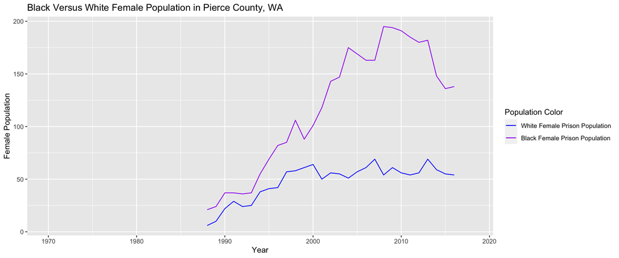

```r
chart_1
```

### Variable Comparison Chart

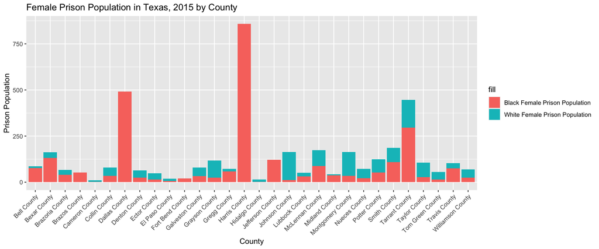

```r
chart_2
```

### Map

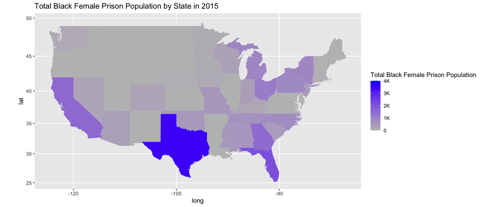

```r
prison_pop_map
```